# Capstone_week1

Yineng Chen

7/9/2020

# Task 2 - Exploratory Data Analysis

## Load Data

```r
fileName="./data/en_US/en_US.blogs.txt"
con=file(fileName,open="r")
lineBlogs=readLines(con，encoding = "UTF-8")
close(con)

con <- file("./data/en_US/en_US.twitter.txt")
linetwitter = readLines(con,skipNul = TRUE，encoding = "UTF-8")
close(con)


con <- file("./data/en_US/en_US.news.txt")
linenews = readLines(con,skipNul = TRUE，encoding = "UTF-8")
close(con)
```

## Take sample

```r
set.seed(1110)

blog_sample = sample(lineBlogs, length(lineBlogs) * 0.01)
twitter_sample = sample(linetwitter, length(linetwitter) * 0.01)
news_sample = sample(linenews, length(linenews) * 0.01)

write.table(news_sample,
            file = "./data/en_US/sample/en_US.news.txt", sep = "\t",
            row.names = FALSE)
write.table(twitter_sample,
            file = "./data/en_US/sample/en_US.twitter.txt", sep = "\t",
            row.names = FALSE)
write.table(blog_sample,
            file = "./data/en_US/sample/en_US.blog.txt", sep = "\t",
            row.names = FALSE)
```

## Read in sample

```r
sample_read <- readtext("./data/en_US/sample/*.txt",
                 dvsep = "_",
                  docvarsfrom = "filenames",
                    docvarnames = c("language","resource"))
```

## remove Non-English Words

```r
# remove Non-English Words
english <- iconv(sample_read,"latin1","ASCII",sub = "")
```

## construt a corpus

```r
# construt a corpus
sample_crop <- corpus(sample_read)

# Summarize
summ = as.data.frame(summary(sample_crop))

summ$Size <- c(format(object.size(sample_read[1,2]), "GB", digits = 4),
             format(object.size(sample_read[2,2]), "GB", digits = 4),
             format(object.size(sample_read[3,2]), "GB", digits = 4))

x1 <- summ$Size[1]
x1 <- as.numeric(stringr::word(x1, 1, 1))

x2 <- summ$Size[2]
x2 <- as.numeric(stringr::word(x2, 1, 1))

x3 <- summ$Size[3]
x3 <- as.numeric(stringr::word(x3, 1, 1))

summ$TTR <- round(c(summ$Types/summ$Tokens), 3)


totaltable = data.frame(Text = "Total",
                 Types = sum(summ$Types),
                 Tokens = sum(summ$Tokens),
                 Sentences = sum(summ$Sentences),
                 Size = paste(sum(x1,x2,x3), "Gb", sep = " "),
                 TTR = sum(round(c(summ$Types/summ$Tokens), 3)))

summ = rbind(summ[,c(1,2,3,4,7,8)],totaltable)

knitr::kable(summ, caption = "Summary description of the sample English corpus")
```

Summary description of the sample English corpus

| Text | Types | Tokens | Sentences | Size | TTR |
| --- | --- | --- | --- | --- | --- |
| en_US.blog.txt | 36032 | 452439 | 21062 | 0.0019 Gb | 0.080 |
| en_US.news.txt | 7980 | 34024 | 1506 | 2e-04 Gb | 0.235 |
| en_US.twitter.txt | 34586 | 418955 | 26344 | 0.0016 Gb | 0.083 |
| Total | 78598 | 905418 | 48912 | 0.0037 Gb | 0.398 |

## tokens

```r
options(width = 110)
# tokens , remove numbers, punctuations and symbols

sample_tokens <- tokens(sample_crop,
                       remove_punct = TRUE,
                       remove_numbers = TRUE,
                       remove_symbols = TRUE)
```

## what are the distributions of word frequencies?

Most frequent words with more than 5 charecters. Creat a word cloud for these words that appears more than 150 times.

```r
# creat document feature matrix
sample_dfm <- dfm(sample_tokens,remove = stopwords("english"), stem = TRUE)
# ndoc(sample_dfm)
# nfeat(sample_dfm)
# topfeatures(sample_dfm, 10)

# select : minimum character = 5
sample_dfm_long <- dfm_select(sample_dfm, min_nchar = 5)
top15_1g = topfeatures(sample_dfm_long, 15)  # top 10
top15_1g
```

```
##  thank  think  peopl  great  thing follow realli  today  right  first  still  start  night  littl  happi
##   1535   1289   1199   1146   1054    994    988    984    934    927    743    725    690    680    676
```

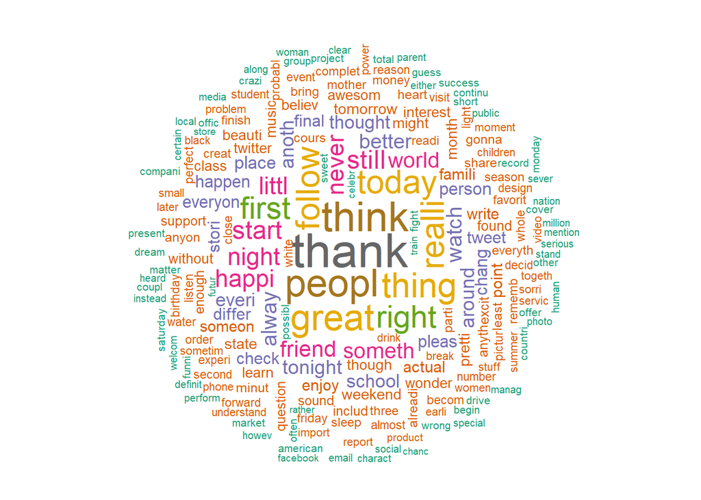

```r
# word cloud for long token (nchar >= 5)
textplot_wordcloud(sample_dfm_long, min_count = 150, random_order = FALSE,
                   rotation = .25,
                   colors = RColorBrewer::brewer.pal(8,"Dark2"))
```

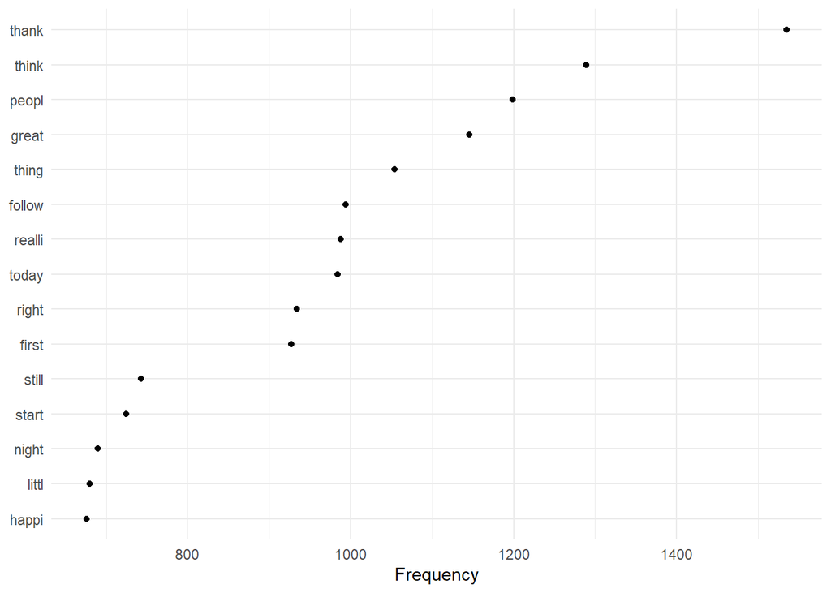

```r
sample_dfm_long %>%
  textstat_frequency(n = 15) %>%
  ggplot(aes(x = reorder(feature, frequency), y = frequency)) +
  geom_point() +
  coord_flip() +
  labs(x = NULL, y = "Frequency") +
  theme_minimal()
```

## What are the frequencies of 2-grams and 3-grams in the dataset?

### Top 15 2-grams

Most frequent 2-grams with more than 10 charecters.

```r
tokens_2gram  <- tokens_ngrams(sample_tokens, n = 2)
# head(tokens_2gram[[1]], 20)

# creat document feature matrix
sample_dfm_2g <- dfm(tokens_2gram,remove = stopwords("english"), stem = TRUE)
# ndoc(sample_dfm_2g)
# nfeat(sample_dfm_2g)
# sample_dfm_2g[,1:4]

sample_dfm_2g_long <- dfm_select(sample_dfm_2g, min_nchar = 10)
top15_2g = topfeatures(sample_dfm_2g_long, 15)
top15_2g
```

```
##     talk_about     last_night     forward_to   look_forward     can't_wait     the_follow     would_have
##            185            176            154            151            146            145            141
##    through_the     around_the    think_about     my_favorit     don't_know     think_that     you_should
##            141            122            121            115            110             96             93
## happi_birthday
##             93
```

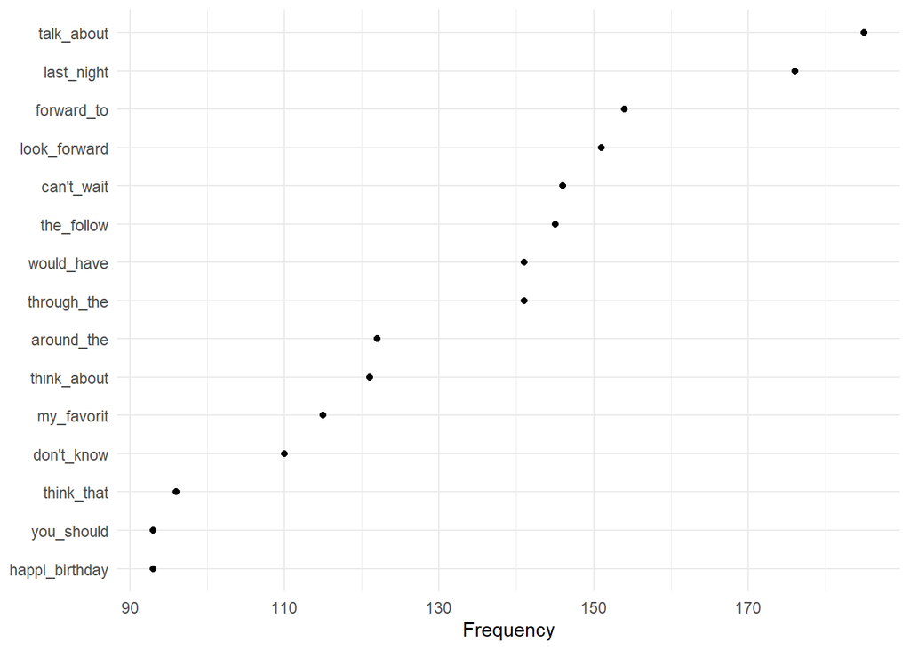

```r
sample_dfm_2g_long %>%
  textstat_frequency(n = 15) %>%
  ggplot(aes(x = reorder(feature, frequency), y = frequency)) +
  geom_point() +
  coord_flip() +
  labs(x = NULL, y = "Frequency") +
  theme_minimal()
```

### Top 10 3-grams

Most frequent 3-grams with more than 15 charecters.

```r
tokens_3gram  <- tokens_ngrams(sample_tokens, n = 3)
# head(tokens_3gram[[1]], 20)


# creat document feature matrix
sample_dfm_3g <- dfm(tokens_3gram,remove = stopwords("english"), stem = TRUE)
# ndoc(sample_dfm_3g)
# nfeat(sample_dfm_3g)
# sample_dfm_3g,1:4]

sample_dfm_3g_long <- dfm_select(sample_dfm_3g, min_nchar = 15)
topfeatures(sample_dfm_3g_long, 10)
```

```
##        look_forward_to       thank_for_follow        would_have_been        pleas_follow_me
##                    148                     34                     33                     33
##        don't_know_what       happi_mother_day  style_background_none background_none_repeat
##                     31                     31                     30                     30
##     none_repeat_scroll   repeat_scroll_yellow
##                     30                     30
```

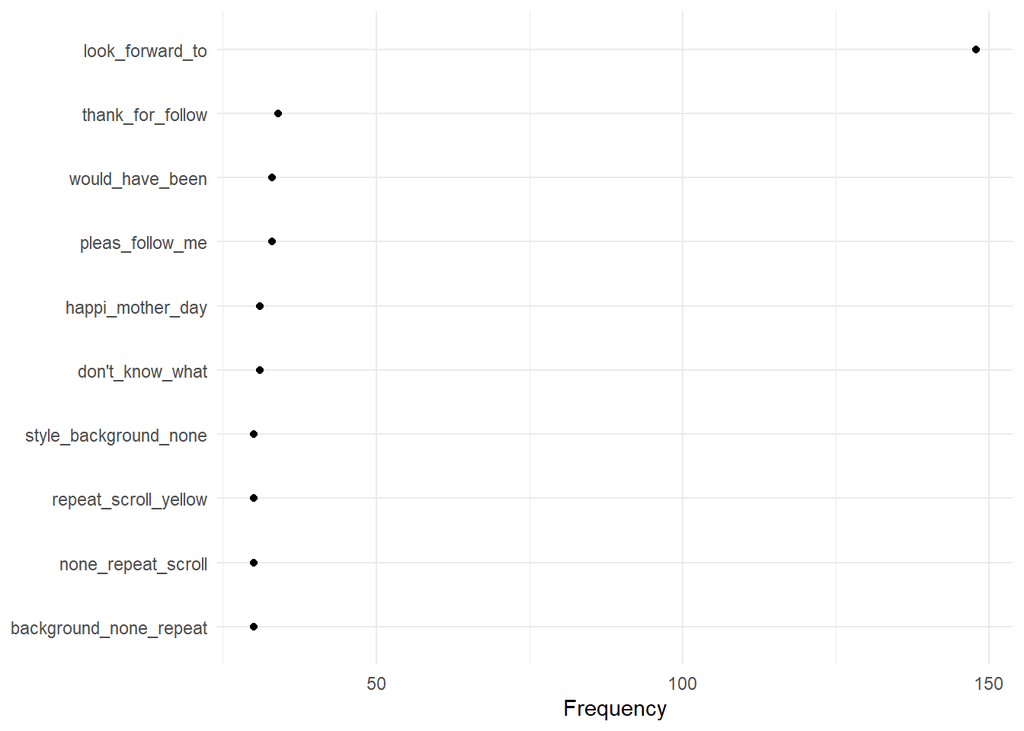

```r
sample_dfm_3g_long %>%
  textstat_frequency(n = 10) %>%
  ggplot(aes(x = reorder(feature, frequency), y = frequency)) +
  geom_point() +
  coord_flip() +
  labs(x = NULL, y = "Frequency") +
  theme_minimal()
```

## How many unique words do you need in a frequency sorted dictionary to cover 50%

We need 109 unique words to cover 50% of all word instances in the language and 3461 unique words to cover 90%.

```r
dfm_token_all <- dfm(sample_tokens, stem = TRUE)

# get frequency of each words
fre = textstat_frequency(dfm_token_all)

# total number of words
totalfreq = sum(fre$frequency) # 698547

sumCover = 0
maxlimt = length(fre$frequency)  # number of unique words 34013

for(i in 1: maxlimt) {
  sumCover <- sumCover + fre$frequency[i]
  if(sumCover >= 0.5*totalfreq){break}
}
print(i) # 109
```

```
## [1] 109
```

```r
sumCover = 0
maxlimt = length(fre$frequency)
for(i in 1: maxlimt) {
  sumCover <- sumCover + fre$frequency[i]
  if(sumCover >= 0.9*totalfreq){break}
}
print(i) # 3461
```

```
## [1] 3461
```

## How do you evaluate how many of the words come from foreign languages?

The Unicode Standard is the universal character encoding standard used for representation of text for computer processing. UTF-8 (8-bit Unicode Transformation Format) is a variable-width character encoding capable of encoding all 1,112,064 valid characters. Unicode Supported scripts include not only pan-European scripts and Asian scripts but also complex text layout scripts such as Arabic, Hebrew, Hindi, and Thai. We could identify foreign language using code table available online. Chick [here] http://www.unicode.org/standard/supported.html for more detals.